# Final Project

Hui

2025-04-05

```r
library(ISLR2)
library(readr)
library(glmnet)
library(randomForest)
library(softImpute)
```

## Part 1: Data cleaning / clustering (30%)

```r
# import data
MAS202M_2025_synthetic_data_20250313<- read_csv("/Users/huiyun/Desktop/tölfræði/MAS202M/exercise/MAS202M_2025_synthetic_data_20250313.csv")
# remove index from the data frame
my_data <- MAS202M_2025_synthetic_data_20250313[, -1]

# display data
head(my_data)
```

| id | col1 | col2 | col3 | col4 | col5 | col6 |
| --- | --- | --- | --- | --- | --- | --- |
| sample74 | 1.02786410 | -13.73604503 | 113.57466 | -15.994390 | 0.00180035 | 113.57466 |
| sample860 | 0.77965149 | -10.75721103 | 97.17057 | -20.520187 | 0.21747601 | 97.17057 |
| sample1631 | 0.08418434 | 2.15253317 | 130.90802 | 5.077833 | 0.48646041 | 130.90802 |
| sample1536 | -0.92157257 | -5.06852247 | 143.98624 | 45.164685 | 0.27710226 | 143.98624 |
| sample1652 | -0.84971236 | 0.01119643 | 78.31526 | 44.647674 | 0.93015591 | 78.31526 |
| sample291 | -1.47138044 | 4.75190807 | 116.24689 | 66.918247 | -1.81288174 | 116.24689 |

### 1

Prepare the provided data set (or another data set of your choice) for further analysis. Using the tools at disposal for data cleaning, prepare the data set to maximize the expected performance of a clustering algorithm trained on the data set. Note the steps taken regardless of whether or not they result in modifications to the data set.

```r
# check dimention
dim(my_data)
```

```
## [1] 1790    7
```

```r
# Check for duplicate rows
cat('number of duplicates:' ,sum(duplicated(my_data)), '\n')
```

```
## number of duplicates: 96
```

```r
# Remove duplicate rows
my_data_unique <- my_data[!duplicated(my_data), ]

# check duplicates have removed
dim(my_data_unique)
```

```
## [1] 1694    7
```

```r
# Check for missing values
colSums(is.na(my_data_unique))
```

```
##   id col1 col2 col3 col4 col5 col6
##   11    4    9    9    5    4    8
```

First, apply matrix completion to data using the softImpute package, which provides a very eﬀicient implementation of a generalization of algorithm 12.1 in Book (An Introduction to Statistical Learning)

```r
# Create data frame without id
df <- my_data_unique[,-1]

# Convert the dataframe to a matrix (softImpute works with matrices)
matrix_data <- as.matrix(df)

# Perform matrix completion using softImpute
imputed_matrix <- softImpute(matrix_data)

# Access the completed matrix (imputed values)
completed_matrix <- imputed_matrix$u %*% diag(imputed_matrix$d) %*% t(imputed_matrix$v)

# Convert the completed matrix back to a dataframe
imputed_df <- as.data.frame(completed_matrix)
colnames(imputed_df) <- colnames(df) # Preserve column names

# Check for missing values again
colSums(is.na(imputed_df))
```

```
## col1 col2 col3 col4 col5 col6
##    0    0    0    0    0    0
```

Second, give missing values in id column temporary sample names.

```r
# combined id to dataframe after matrix completion
my_data_cleaned <- data.frame(
  id = my_data_unique$id,
  col1 = imputed_df$col1,
  col2 = imputed_df$col2,
  col3 = imputed_df$col3,
  col4 = imputed_df$col4,
  col5 = imputed_df$col5,
  col6 = imputed_df$col6
)

# Identify rows with NA in the 'id' column
na_id_rows <- is.na(my_data_cleaned$id)

# Create new id values (missing1 to missingn)
new_ids <- paste0("missing", 1:sum(na_id_rows))

# Replace NA values in the 'id' column with the new IDs
my_data_cleaned$id[na_id_rows] <- new_ids

# Print the new IDs
print(my_data_cleaned$id[na_id_rows])
```

```
##  [1] "missing1"  "missing2"  "missing3"  "missing4"  "missing5"  "missing6"
##  [7] "missing7"  "missing8"  "missing9"  "missing10" "missing11"
```

```r
# Check the results
print(colSums(is.na(my_data_cleaned)))
```

```
##   id col1 col2 col3 col4 col5 col6
##    0    0    0    0    0    0    0
```

Now the data is ready for clustering.

### 2

Build a model to cluster the data set. Describe the resulting classifier and its performance, i.e., how it clusters the data.

#### Perform K-means clusteringr in pricipal components

First briefly examine the data.

```r
apply(my_data_cleaned[,-1] , 2, mean)
```

```
##       col1       col2       col3       col4       col5       col6
## -0.5145648  0.7118292 82.9789934 25.8972349 -0.1780429 82.9806033
```

Notice that the variables have vastly different means.

```r
apply(my_data_cleaned[,-1] , 2, var)
```

```
##         col1         col2         col3         col4         col5         col6
## 5.620875e-01 9.908611e-02 9.534890e+02 1.629147e+03 4.203552e-03 9.537521e+02
```

the variables also have vastly different variances.  
We have to scale the data, because PCA is sensitive to the variances of the original variables. If variables have significantly different scales, the variables with larger variances will dominate the PCA process.

```r
# Select numeric variables
df<- my_data_cleaned[, -1]

# Perform PCA with scaled data
pr.out <- prcomp(df , scale = TRUE)

#variance explained by each principal component
pr.var <- pr.out$sdev ^2
pr.var
```

```
## [1] 3.790689e+00 2.209311e+00 7.526176e-29 1.259614e-30 7.605732e-31
## [6] 3.539482e-32
```

Compute the proportion of variance explained by each principal component, divide the variance explained by each principal component by the total variance explained by all 6 principal components:

```r
# proportion of variance explained by each principal component
pve <- pr.var / sum(pr.var)
pve
```

```
## [1] 6.317816e-01 3.682184e-01 1.254363e-29 2.099356e-31 1.267622e-31
## [6] 5.899136e-33
```

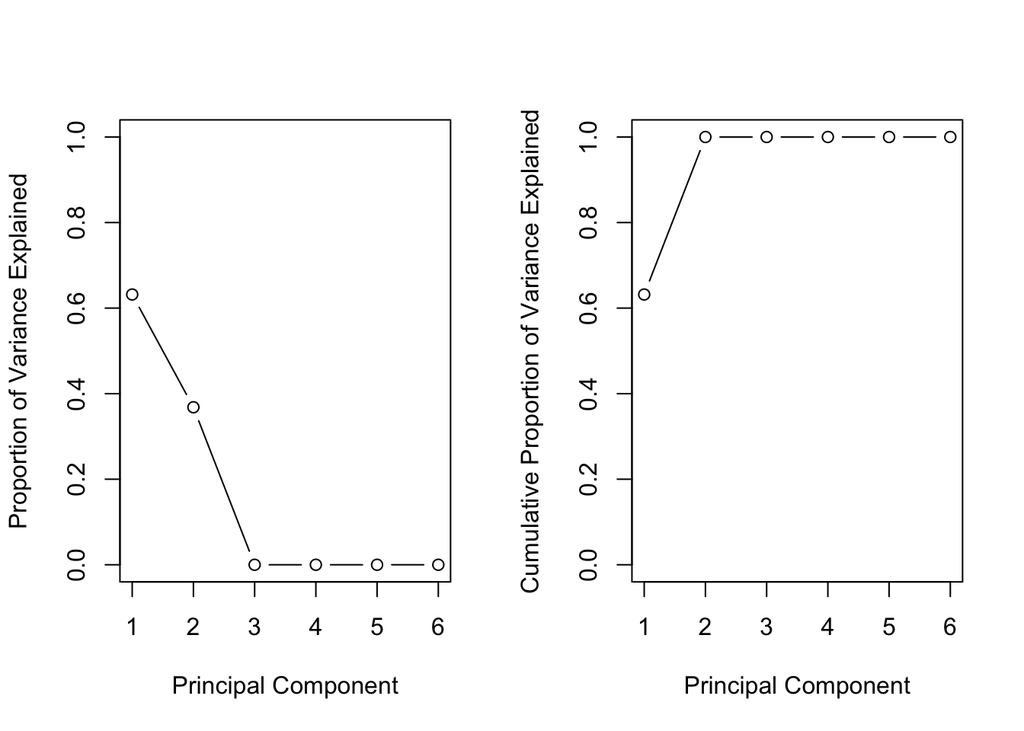

```r
# plot results
par(mfrow = c(1, 2))

plot(pve , xlab = " Principal Component ", ylab = " Proportion of Variance Explained ", ylim = c(0, 1), type = "b")

plot(cumsum(pve), xlab = " Principal Component ", ylab = " Cumulative Proportion of Variance Explained ", ylim = c(0, 1), type = "b")
```

We see that the first principal component explains 63.2 % of the variance in the data, the next principal component explains 36.8 % of the variance, and so forth. PCA help reduce dimentions.

We then use first 2 components for k-mean clustering:

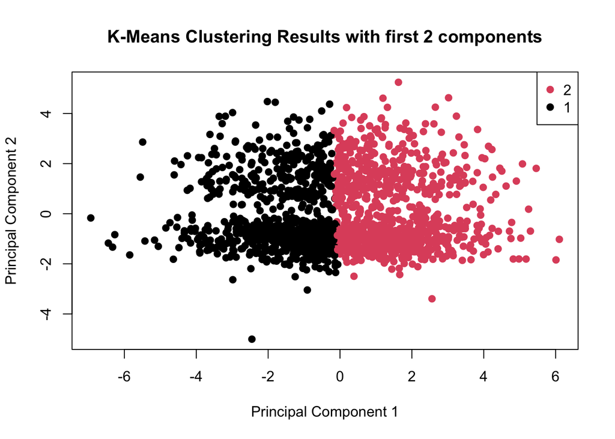

```r
# Extract the first two principal components
pcs <- pr.out$x[, 1:2]

# K-means clustering for first two principal components
# K = 2
kmeans_result <- kmeans(pcs, centers = 2)

# Plot clusters
plot(pcs[, 1], pcs[, 2], col = kmeans_result$cluster, pch = 19, xlab = "Principal Component 1", ylab = "Principal Component 2", main = "K-Means Clustering Results with first 2 components")
legend("topright", legend = unique(kmeans_result$cluster), col = unique(kmeans_result$cluster), pch = 19)
```

k-means clustering assigns data points to clusters and updates the cluster centroids to minimize the distance between data points and their respective cluster centers.

## Part 2: Prediction / inference (70%)

For this section, we provide a data set containing the levels of 100 proteins measured in the plasma of 384 individuals, given on a relative scale (NPX) provided by the manufacturer of the measurement platform.

The data set is derived from the MGH-COVID 19 study, provided as supplementary materials with the paper by Filbin and co-workers (2021)* and accessible in its raw form at https://info.olink.com/broad-covid-study-overview-download

*Filbin MR, Mehta A … Hacohen N, Goldberg MB. (2021) Longitudinal proteomic analysis of plasma from patients with severe COVID-19 reveal patient survival-associated signatures, tissue-specific cell death, and cell-cell interactions. Cell Rep Med., DOI: 10.1016/j.xcrm.2021.100287.

```r
# import data
MAS202M_2025_proteomics_measurements_20250313 <- read.csv("~/Desktop/tölfræði/MAS202M/exercise/MAS202M_2025_proteomics_measurements_20250313.csv")
MAS202M_2025_clinical_info_20250313 <- read.csv("~/Desktop/tölfræði/MAS202M/exercise/MAS202M_2025_clinical_info_20250313.csv")
```

### data preparation

```r
# check structure of the data
str(MAS202M_2025_proteomics_measurements_20250313)
```

```
## 'data.frame':    37917 obs. of  4 variables:
##  $ subject_id: int  1 1 1 1 1 1 1 1 1 1 ...
##  $ OlinkID   : chr  "OID20105" "OID21188" "OID21243" "OID20658" ...
##  $ Assay     : chr  "ACE2" "ADCYAP1R1" "AGR3" "AGRP" ...
##  $ NPX       : num  -1.4261 -0.0665 -1.8488 -1.1949 -1.4979 ...
```

```r
str(MAS202M_2025_clinical_info_20250313)
```

```
## 'data.frame':    384 obs. of  4 variables:
##  $ subject_id: int  1 2 3 4 5 6 7 8 9 10 ...
##  $ COVID     : int  1 1 1 1 1 1 1 0 1 0 ...
##  $ Age_cat   : int  1 2 3 1 3 1 2 4 5 2 ...
##  $ BMI_cat   : int  4 2 4 2 3 1 2 3 2 2 ...
```

Reshape data frame (MAS202M_2025_proteomics_measurements_20250313), use subject_id as rows and Assay(protein) as column:

```r
data <- MAS202M_2025_proteomics_measurements_20250313

# Get unique subject IDs and Assays(Protein)
subject_ids <- unique(data$subject_id)
assays <- unique(data$Assay)

# Create an empty data frame to store the reshaped data
reshaped_data <- data.frame(subject_id = subject_ids)

# Loop through each Assay and add it as a column
for (assay in assays) {
  reshaped_data[[assay]] <- NA # Initialize the column with NA values
  for (i in 1:nrow(reshaped_data)) {
    subject_id <- reshaped_data$subject_id[i]
    # Find the corresponding NPX value for the subject_id and Assay
    npx_value <- data$NPX[data$subject_id == subject_id & data$Assay == assay]
    if (length(npx_value) > 0) {
      reshaped_data[[assay]][i] <- npx_value[1] # Assign the first matching value
    }
  }
}
```

```r
# check reshaped_data dimention
dim(reshaped_data)
```

```
## [1] 383 100
```

There are 383 individuals and 99 protein information in the reshape data set.

```r
# merge 2 data frame together by subject_id
merge_df <- merge(reshaped_data, MAS202M_2025_clinical_info_20250313, by = "subject_id")

# check dimention
dim(merge_df)
```

```
## [1] 383 103
```

```r
# Convert qualitative variables into factors
merge_df$subject_id <- as.factor(merge_df$subject_id)
merge_df$COVID <- as.factor(merge_df$COVID)
merge_df$Age_cat <- as.factor(merge_df$Age_cat)
merge_df$BMI_cat <- as.factor(merge_df$BMI_cat)
```

age group (1=20-34, 2=36-49, 3=50-64, 4=65-80, 5=80+)  
BMI group (0=<18.5, 1=18.5-24.9, 2=25.0-29.9, 3=30.0-39.9, 4=>40, 5=unknown)  
Covid group (0=no, 1=yes)

```r
# check missing and duplicate value
anyDuplicated(merge_df)
```

```
## [1] 0
```

```r
anyNA(merge_df)
```

```
## [1] FALSE
```

```r
# display cleaned data frame
head(merge_df)
```

|  | subject_id | ACE2 | ADCYAP1R1 | AGR3 | AGRP | AKR1B1 | APRT | ARG1 | AXL | B4GALT1 | B4GAT1 | BCAM | BID | BPIFB1 | CALB2 | CASP8 | CD22 | CD27 | CD33 | CD38 | CD48 | CDKN1A | CDNF | CEACAM21 | CES2 | CLC | CLEC1A | CLUL1 | COPE | … |
| --- | --- | --- | --- | --- | --- | --- | --- | --- | --- | --- | --- | --- | --- | --- | --- | --- | --- | --- | --- | --- | --- | --- | --- | --- | --- | --- | --- | --- | --- | --- |
| 1 | 1 | -1.4261 | -0.0665 | -1.8488 | -1.1949 | -1.4979 | 2.6879 | -0.5573 | -2.4020 | -2.0928 | -2.6878 | -2.1914 | -0.7821 | -2.2680 | 0.3215 | 0.5207 | -1.2351 | -2.0042 | -2.7134 | -1.6443 | -2.0154 | 3.7895 | -2.2213 | -1.0447 | -1.6269 | -2.1170 | -2.0009 | -1.6905 | -0.6419 | … |
| 2 | 2 | -2.0836 | 0.1118 | -0.7703 | -0.8051 | 0.8128 | 3.8750 | 0.1441 | -2.0480 | -1.6115 | -2.3120 | -2.2588 | 0.1469 | -2.7083 | -0.5550 | 1.7401 | -0.9868 | -2.6313 | -2.2982 | -1.4676 | -1.5127 | 4.6729 | -2.3241 | -2.4264 | -2.0630 | -2.1208 | -1.2747 | -1.9122 | -0.0651 | … |
| 3 | 3 | -0.3594 | -0.1814 | -0.7075 | 1.8155 | 0.3256 | 2.3342 | 0.0312 | -0.7457 | -0.0091 | -2.2197 | -1.2494 | -0.2815 | -1.5048 | 0.0356 | 1.0241 | -1.3777 | -1.4391 | -2.2805 | -0.8509 | -0.9792 | 3.3411 | -1.3890 | 1.2182 | -1.5298 | -1.7778 | -0.6315 | -1.4628 | 0.7837 | … |
| 4 | 4 | -2.4722 | -0.3032 | 0.0845 | -1.0932 | -0.7050 | 3.1841 | 1.6858 | -2.2267 | -2.1445 | -2.6085 | -1.9213 | -0.2881 | -2.0501 | -0.8360 | 0.7366 | -1.4198 | -2.7125 | -1.6559 | -1.6336 | -1.8988 | 0.6388 | -3.0086 | -3.0894 | -2.0014 | -2.1416 | -1.6374 | -1.6946 | -0.2671 | … |
| 5 | 5 | -1.6993 | 0.0913 | -0.0364 | -0.6008 | -0.4118 | 2.7066 | 1.5528 | -1.7460 | -1.0865 | -2.2945 | -1.5474 | 0.2234 | -1.7496 | -0.0877 | 1.3974 | -0.7448 | -2.2944 | -2.8569 | -1.4422 | -1.2522 | 1.0372 | -2.1825 | 0.0391 | -1.1166 | -1.8873 | -1.2005 | -1.7776 | -0.5561 | … |
| 6 | 6 | -1.4781 | 0.2107 | -1.1980 | 0.9828 | 0.2059 | 2.5764 | -0.7074 | -1.7871 | -1.2892 | -2.0649 | -0.6099 | -0.4457 | -1.5234 | -0.2096 | 1.0213 | -1.6211 | -2.4641 | -2.8667 | -1.1693 | -0.9335 | 3.2171 | -2.3963 | -2.2458 | -2.7585 | -1.6739 | -0.5333 | -0.0862 | -0.3754 | … |

### 1

`Goal` Pick a quantitative variable (CD38) in the data set. Build a regression for the variable using two different methods. Use the models for prediction. One models for linear regression, the other for non-linear relationships between dimensions. Tune the parameters of each regression model and compare their performances. Discuss the outcome, including the strengths and weaknesses of each type of regression model relative to the data set. What (if anything) can we infer about the structure of the data from the models.  
We use variables (NPX values in proteins, age, BMI and COVID index) in the data set to predict NPX value (quantitative variable) in protein CD38

#### Ridge Regression

Strengths of Ridge Regression:  
Use lambda (λ) as a Regularization Parameter. A larger lambda value leads to greater shrinkage, meaning the coefficients are pushed closer to zero. This shrinkage helps to prevent overfitting, particularly when we have many predictors or when predictors are highly correlated (multicollinearity).  
Weaknesses of Ridge Regression:  
Doesn’t perform feature selection, all predictors will be used in the model.

```r
# remove subject_id from data set
df <- merge_df[,-1]

# split data to train and test data
# 2 methods will use same train and test data for comparison
set.seed (1)
train <- sample (1: nrow(df), nrow(df) / 2)
```

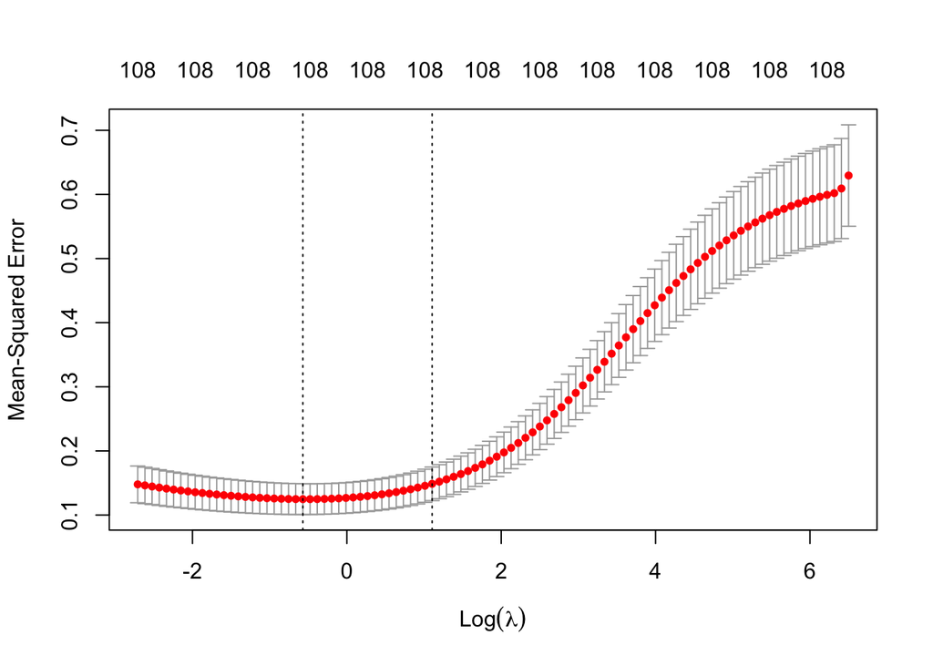

```r
# Ridge Regression use glmnet()

# Prepare the data for glmnet (glmnet needs a matrix of predictors)
# Remove intercept
x <- model.matrix(CD38 ~ ., data = df[train,])[, -1]
y <- df[train,]$CD38

# Cross-validation for Ridge (alpha = 0 for Ridge, 10-fold CV)
set.seed(1)
ridge_cv <- cv.glmnet(x, y, alpha = 0, nfolds = 10)
plot(ridge_cv)
```

```r
# Best lambda from cross-validation
best_lambda_ridge <- ridge_cv$lambda.min
cat('Best lambda:', best_lambda_ridge, '\n')
```

```
## Best lambda: 0.56557
```

```r
# Ridge model with best lambda
ridge_model <- glmnet(x, y, alpha = 0, lambda = best_lambda_ridge)
```

```r
# Predictions
x <- model.matrix(CD38 ~ ., data = df[-train,])[, -1]
y <- df[-train,]$CD38

ridge_predictions <- predict(ridge_model, newx = x)

# Performance evaluation (MSE)
ridge_mse <- mean((ridge_predictions - y)^2)
cat("test data MSE (Ridge Regression):", ridge_mse)
```

```
## test data MSE (Ridge Regression): 0.09507384
```

Plot the predicted values from Ridge model against the actual target values.

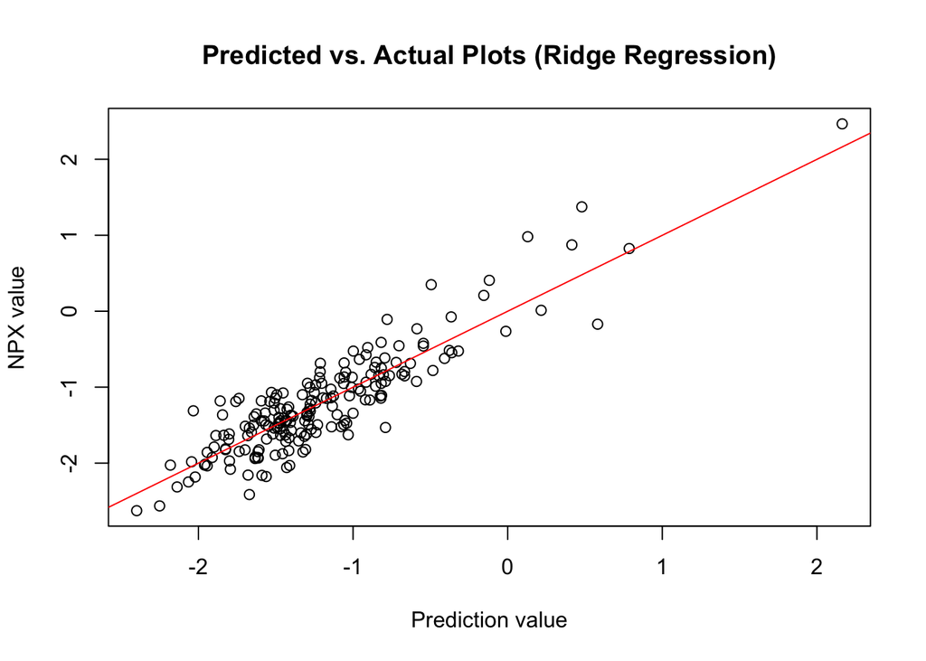

```r
plot(ridge_predictions, y, xlab = "Prediction value", ylab = "NPX value", main = "Predicted vs. Actual Plots (Ridge Regression)")
abline(0, 1, col = "red")
```

#### Bagging (Random Forests)

bagging is a special case of a random forest with m = p.  
p represents the total number of predictors (or features) in the dataset.  
m represents the number of predictors randomly selected at each split when building a decision tree within the random forest.  
Strengths:  
Random forests provide a measure of feature importance, allowing to identify the most influential variables in the model.  
Weakness:  
Random forests are less interpretable. Training a large number of trees can be computationally expensive, especially with large datasets.

```r
# bagging m = p
n<- ncol(df)-1

set.seed(1)
bag<- randomForest(CD38~., data = df, subset = train, mtry = n, importance = TRUE)
bag
```

```
##
## Call:
##  randomForest(formula = CD38 ~ ., data = df, mtry = n, importance = TRUE,      subset = train)
##                Type of random forest: regression
##                      Number of trees: 500
## No. of variables tried at each split: 101
##
##           Mean of squared residuals: 0.1475614
##                     % Var explained: 76.39
```

All variables are used in this model.

```r
# prediction in test data
yhat.bag <- predict(bag, newdata = df[-train , ])
cat("test set MSE (Bagging):", mean (( yhat.bag - df[-train,]$CD38)^2), "\n")
```

```
## test set MSE (Bagging): 0.1282214
```

ntree determines how many individual decision trees the random forest will construct. Generally, a larger ntree leads to more stable and reliable results.

```r
# tune parameter ntree = 1000
set.seed(1)
bag<- randomForest(CD38~., data = df, subset = train, mtry = n, ntree = 1000, importance = TRUE)

# prediction in test data set
yhat.bag <- predict(bag, newdata = df[-train , ])
cat("test set MSE (Bagging):", mean (( yhat.bag - df[-train,]$CD38)^2), "\n")
```

```
## test set MSE (Bagging): 0.1285619
```

Plot the predicted values from Bagging model against the actual target values.

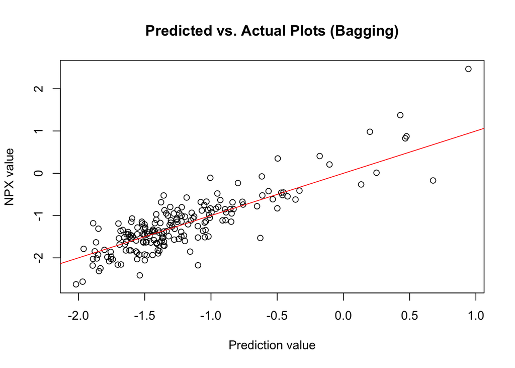

```r
plot(yhat.bag, df[-train,]$CD38, xlab = "Prediction value", ylab = "NPX value", main = "Predicted vs. Actual Plots (Bagging)")
abline(0, 1, col = "red")
```

View the importance of variables.

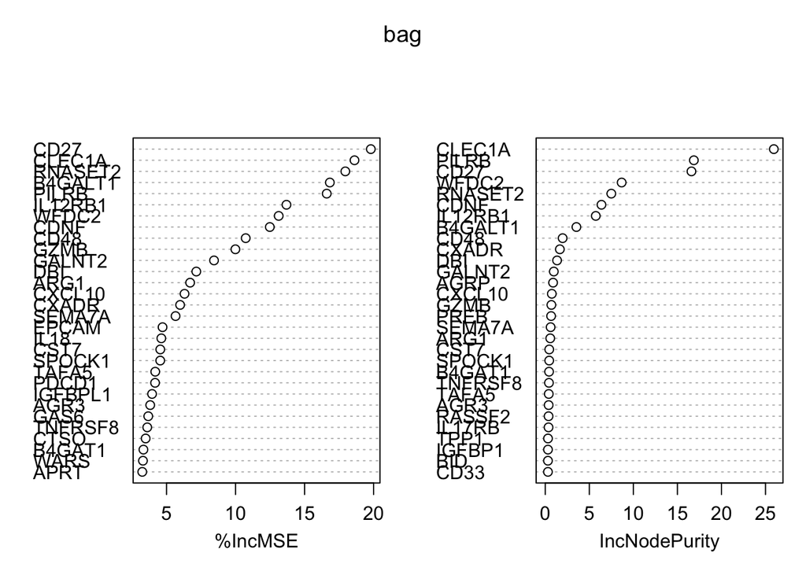

```r
varImpPlot(bag)
```

```r
# Get variable importance
importance_scores <- importance(bag)

# Sort importance scores in descending order
sorted_importance <- importance_scores[order(importance_scores[, 1], decreasing = TRUE),  ,drop = FALSE]

# Print the names of the top 10 most important variables
top_10_variables <- rownames(sorted_importance)[1:min(10, nrow(sorted_importance))]
print("Top 10 most important variables:")
```

```
## [1] "Top 10 most important variables:"
```

```r
print(top_10_variables)
```

```
##  [1] "CD27"    "CLEC1A"  "RNASET2" "B4GALT1" "PILRB"   "IL12RB1" "WFDC2"
##  [8] "CDNF"    "CD48"    "GZMB"
```

#### Compare 2 methods (Ridge regression and bagging)

```r
# result
cat("test set MSE (Ridge Regression):", ridge_mse, '\n')
```

```
## test set MSE (Ridge Regression): 0.09507384
```

```r
cat("test set MSE (Bagging):", mean (( yhat.bag - df[-train,]$CD38)^2), "\n")
```

```
## test set MSE (Bagging): 0.1285619
```

Both methods use all variables to predict CD38. The results indicates that Ridge Regression performed better than Bagging on the test set. It suggests that the relationship between predictors and the target variable (CD38) is more likely to be linear or non-linearities are weak or absent.  
The small difference (0.03) in test set error suggests that while linearity is a good fit, there might be some non-linearities or complexities in the data that bagging could potentially capture.

### 2

`Goal` Pick a categorical variable (COVID) in the data set (or create one by thresholding a continuous variable). Build a classifier for the variable using two different methods. Tune the parameters of each classifier and compare their performances. Discuss the outcome, including the strengths and weaknesses of each type of classifier relative to the data set in question. What (if anything) can we infer about the structure of the data from the models?  
We use NPX values in proteins, age and BMI to predict if a person has COVID or not. (categorical variable = COVID)

#### Lasso regression

Lasso’s primary strength is its ability to perform feature selection by shrinking the coefficients of less important variables to zero. Lasso regression helps to avoid overfitting.  
After a lasso logistic regression is run, a threshold is needed to turn the predicted probabilities into classifications. The chosen threshold has a large impact on the confusion matrix (result).

```r
# Create model matrix
x <- model.matrix(COVID ~ ., data = df[train,])[, -1] # remove intercept
y <- as.factor(df[train,]$COVID)

# Cross-validation to find optimal lambda
cv_lasso <- cv.glmnet(x, y, alpha = 1, family = "binomial")
best_lambda <- cv_lasso$lambda.min
cat('lambda:', best_lambda, '\n')
```

```
## lambda: 0.02134997
```

```r
# Train Lasso logistic regression model with optimal lambda
lasso_model_best <- glmnet(x, y, alpha = 1, family = "binomial", lambda = best_lambda)
```

```r
# Make predictions
x <- model.matrix(COVID ~ ., data = df[-train,])[, -1] # test data
probabilities <- predict(lasso_model_best, newx = x, type = "response")

# threshold = 0.5
predicted_classes <- ifelse(probabilities > 0.5, 1, 0)

# confusion matrix
table(Actual = df[-train,]$COVID, Predicted = predicted_classes)
```

```
##       Predicted
## Actual   0   1
##      0  26   7
##      1   9 150
```

```r
cat('test error rate:', mean(df[-train,]$COVID != predicted_classes))
```

```
## test error rate: 0.08333333
```

Change threshold to see different result.

```r
# Make predictions
probabilities <- predict(lasso_model_best, newx = x, type = "response")

# threshold = 0.4
predicted_classes <- ifelse(probabilities > 0.4, 1, 0)

# confusion matrix
table(Actual = df[-train,]$COVID, Predicted = predicted_classes)
```

```
##       Predicted
## Actual   0   1
##      0  25   8
##      1   7 152
```

```r
cat('test error rate (Lasso):', mean(df[-train,]$COVID != predicted_classes))
```

```
## test error rate (Lasso): 0.078125
```

```r
# Extract coefficients from the best Lasso model
coefficients <- coef(lasso_model_best)

# Convert coefficients to a matrix and then to a data frame for easier handling
coef_matrix <- as.matrix(coefficients)
coef_df <- as.data.frame(coef_matrix)

# Remove the intercept (first row) if needed
coef_df <- coef_df[-1, , drop = FALSE]

# Add variable names as a column
coef_df$variable <- rownames(coef_df)

# Rename the coefficient column
colnames(coef_df)[1] <- "coefficient"

# Filter out variables with zero coefficients (not selected by Lasso)
important_variables <- coef_df[coef_df$coefficient != 0, ]

# Sort by absolute coefficient magnitude (for importance)
important_variables <- important_variables[order(abs(important_variables$coefficient), decreasing = TRUE), ]

# Print the important variables and their coefficients
print(important_variables)
```

```
##          coefficient variable
## AXL      -1.26314044      AXL
## CD48      1.04199155     CD48
## TPP1      0.83548847     TPP1
## CLC      -0.59860387      CLC
## CXCL10    0.56172141   CXCL10
## BMI_cat1 -0.43087641 BMI_cat1
## BMI_cat2  0.42538692 BMI_cat2
## FKBP7     0.38648099    FKBP7
## BID       0.36480001      BID
## ITGA11   -0.33549315   ITGA11
## CES2     -0.30421923     CES2
## IL18      0.28499881     IL18
## CTSO      0.24677096     CTSO
## NCS1     -0.20470464     NCS1
## PSME1     0.07310988    PSME1
## IGFBP1   -0.06255067   IGFBP1
## CXCL6    -0.03602529    CXCL6
```

17 variables are used in Lasso regression to predict if a person has COVID or not.

#### Bagging (Random Forests)

By default, randomForest() uses p/3 variables when building a random forest of regression trees, and √p variables when building a random forest of classification trees.

```r
# tune parameter mtry = √p
set.seed(1)
bag<- randomForest(COVID~., data = df, subset = train, importance = TRUE)
yhat.bag <- predict(bag, newdata = df[-train , ])
cat("test error rate:", mean (yhat.bag != df[-train,]$COVID), "\n")
```

```
## test error rate: 0.1145833
```

Use bagging which is a special case of random Forest.

```r
# use train data to fit model m = p
set.seed (1)
bag<- randomForest(COVID~., data = df, subset = train, mtry = n, importance = TRUE)
bag
```

```
##
## Call:
##  randomForest(formula = COVID ~ ., data = df, mtry = n, importance = TRUE,      subset = train)
##                Type of random forest: classification
##                      Number of trees: 500
## No. of variables tried at each split: 101
##
##         OOB estimate of  error rate: 13.61%
## Confusion matrix:
##    0   1 class.error
## 0 28  17  0.37777778
## 1  9 137  0.06164384
```

```r
# prediction in test data
yhat.bag <- predict(bag, newdata = df[-train , ])
cat("test error rate (Bagging):", mean (yhat.bag != df[-train,]$COVID), "\n")
```

```
## test error rate (Bagging): 0.08854167
```

Baggging perform better with lower test error rate.

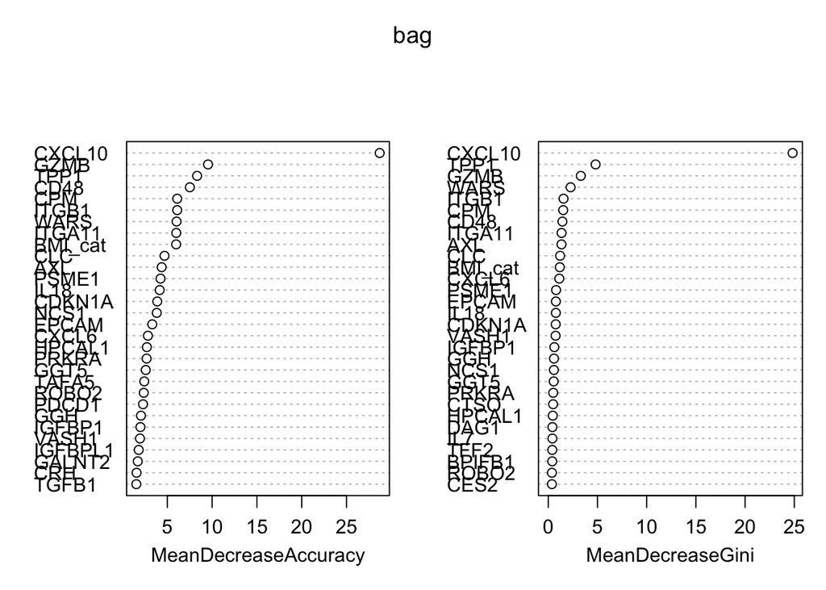

```r
# plot importance
varImpPlot(bag)
```

```r
# Get variable importance
importance_scores <- importance(bag)

# Sort importance scores in descending order
sorted_importance <- importance_scores[order(importance_scores[, 1], decreasing = TRUE), , drop = FALSE]

# Print the names of the top 10 most important variables
top_10_variables <- rownames(sorted_importance)[1:min(10, nrow(sorted_importance))] #handle cases where there are less than 10 variables.
print("Top 10 most important variables used to predict if a person has COVID:")
```

```
## [1] "Top 10 most important variables used to predict if a person has COVID:"
```

```r
print(top_10_variables)
```

```
##  [1] "CXCL10"  "TPP1"    "GZMB"    "BMI_cat" "WARS"    "ITGA11"  "ITGB1"
##  [8] "CPM"     "CLC"     "NCS1"
```

#### Compare 2 mothods (Lasso and Bagging)

```r
cat('test error rate (Lasso):', mean(df[-train,]$COVID != predicted_classes), '\n')
```

```
## test error rate (Lasso): 0.078125
```

```r
cat("test error rate (Bagging):", mean (yhat.bag != df[-train,]$COVID), "\n")
```

```
## test error rate (Bagging): 0.08854167
```

Lasso perform better in test data set, the difference between the error rates is relatively small ($\approx 0.01$).

```r
# Extract variable names from Lasso results
lasso_vars <- important_variables$variable

# Find the intersection (common variables)
common_vars <- intersect(lasso_vars, top_10_variables)

# Print the common variables
print("Variables common to both Lasso and Bagging:")
```

```
## [1] "Variables common to both Lasso and Bagging:"
```

```r
print(common_vars)
```

```
## [1] "TPP1"   "CLC"    "CXCL10" "ITGA11" "NCS1"
```

Among 17 variables Lasso model use and top 10 important variables in Bagging model, there are 5 variables in both methods. This indicates that these variables are important in both linear and non-linear methods to predict if a person has COVID or not.